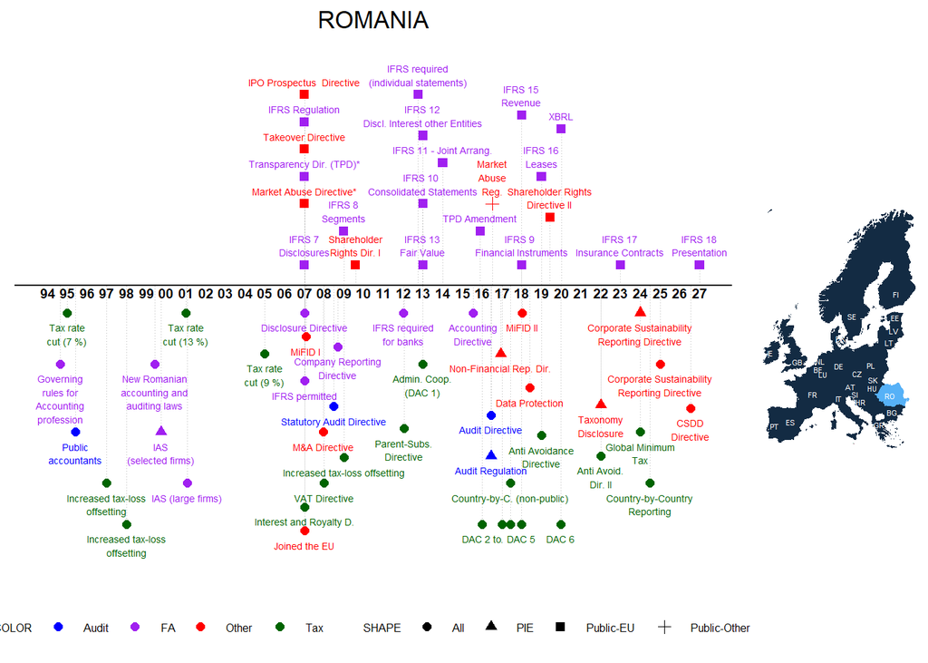

Notes: The graph depicts major regulatory changes that we identified via an extensive literature search, an online survey of mentioned authors, and other sources. Please note that the graph does not include all possible regulatory changes, e.g. minor revisions to local GAAP or tax rate changes below 3% are not included. The dates of EU Directives are based on the official transposition deadlines unless denoted with a *, in which case we included the entry-to-force date as identified in the literature. For more information, please go to [Labro and Pierk (2023)](http://www.eu-regulations.com/Labro_Pierk_2023.pdf). We kindly ask that you cite the paper if you use the information on this website in your research project. Do you have comments or see anything missing? Please email us!

## Regulations, Publications, Further Graphs

The tab ‘Regulations’ includes links to the regulations, gives short descriptions, and provides selective papers for further reading. If the regulation is a national transposition of an EU Directive, the link to the Directive is given. The tab ‘Number of Regulations’ shows graphically the number of regulations 8 years around the respective year (-4,-3,-2,-1,0,+1,+2,+3). The tab ‘Number of Categories” shows graphically the number of different categories 8 years around the respective year (-4,-3,-2,-1,0,+1,+2,+3). The tab ’Publications’ shows all publications that include the countries’ names and variations thereof in the title, abstract, or keywords. Similarly, the tab ‘SSRN’ shows papers of the SSRN Accouning Research Network that include the countries’ names and variations.

### Regulations

|  | Date | Milestones | Applies_to | Category | Description |
| --- | --- | --- | --- | --- | --- |
| 1 | 1994-08-19 | Governing rules for accounting profession | All Firms | FA | Governmental Ordinance No. 65/1994 (Governmental Ordinance No. 65/1994): New rules for the accounting profession See also: Dutia 1995 |
| 2 | 1995-01-01 | Tax rate cut (7 %) | All Firms | Tax | Tax rate cut (7 %): Romania reduced the corporate tax rate by 7 percentage points (from 45 to 38 percent). |
| 3 | 1995-05-30 | Public accountants | All Firms | Audit | Governmental Ordinance No. 3/1995 (Governmental Ordinance No. 3/1995): "Obligation to verify and certify the balance sheet even for commercial companies lacking an auditor if the turnover is greater t… |
| 4 | 1997-01-01 | Increased tax-loss offsetting | All Firms | Tax | Increased tax-loss offsetting: Tax loss carryforwards was increased from 2 to 3 years. See also: Dreßler and Overesch 2013 |
| 5 | 1998-01-01 | Increased tax-loss offsetting | All Firms | Tax | Increased tax-loss offsetting: Tax loss carryforwards was increased from 3 to 5 years. See also: Dreßler and Overesch 2013 |
| 6 | 1999-06-01 | New Romanian accounting and auditing laws | All Firms | FA | OUG 75/1999: Increased audit requirements: verification of consistency between annual reports and annual accounts is required. See also: King, Beattie, Cristescu, and Weetman 2001 |
| 7 | 1999-10-04 | IAS (selected firms) | PIE | FA | ORDIN nr. 403 din 22 aprilie 1999 pentru aprobarea Reglementărilor contabile armonizate cu Directiva a IV-a a Comunităţilor Economice Europene şi cu Standardele de Contabilitate Internaţionale (ORDER … |
| 8 | 2001-01-01 | Tax rate cut (13 %) | All Firms | Tax | Tax rate cut (13 %): Romania reduced the corporate tax rate by 13 percentage points (from 38 to 25 percent). |
| 9 | 2001-01-29 | IAS (large firms) | All Firms | FA | ORDIN nr. 94 din 29 ianuarie 2001, pentru aprobarea Reglementărilor contabile armonizate cu Directiva a IV-a a Comunităţilor Economice Europene şi cu Standardele Internaţionale de Contabilitate (ORDER… |
| 10 | 2005-01-01 | Tax rate cut (9 %) | All Firms | Tax | Tax rate cut (9 %): Romania reduced the corporate tax rate by 9 percentage points (from 25 to 16 percent). |

[output cut: 55 more lines]

### Number of Regulations

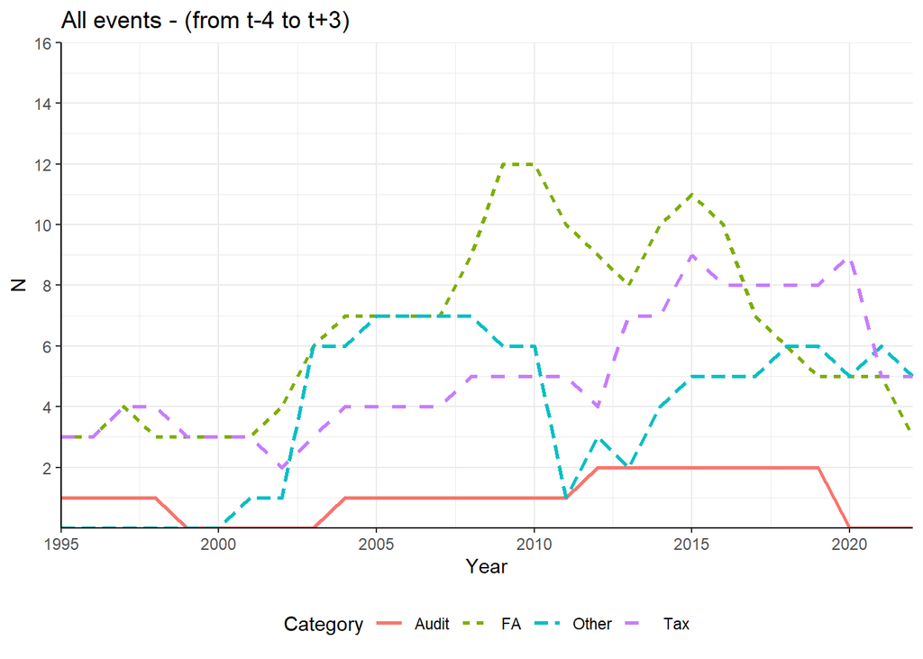

### Number of Categories

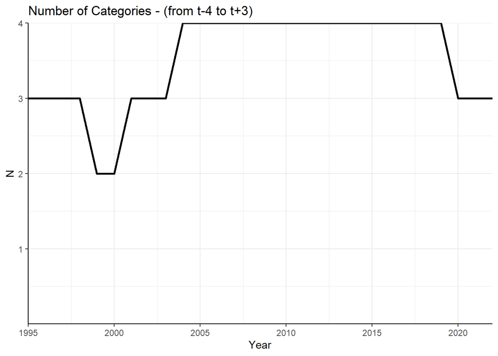

### Publications

|  | authors | title | year | journal |
| --- | --- | --- | --- | --- |
| 1 | Dragomir V.D., Dumitru M., Feleagă L. | political interventions in state-owned enterprises: the corporate governance failures of a european airline | 2021 | Journal of Accounting and Public Policy |
| 2 | Nicolae Albu C., Albu N., Hoffmann S. | the westernisation of a financial reporting enforcement system in an emerging economy | 2021 | Accounting and Business Research |
| 3 | Albu N., Albu C.N., Apostol O., Cho C.H. | the past is never dead: the role of imprints in shaping social and environmental reporting in a post-communist context | 2020 | Accounting, Auditing and Accountability Journal |
| 4 | Albu C.N., Albu N. | the role and current status of ifrs in the completion of national accounting rules–evidence from romania | 2017 | Accounting in Europe |
| 5 | Dumitru M., Dyduch J., Gușe R.-G., Krasodomska J. | corporate reporting practices in poland and romania–an ex-ante study to the new non-financial reporting european directive | 2017 | Accounting in Europe |
| 6 | Apostol O.M. | a project for romania? the role of the civil society’s counter-accounts in facilitating democratic change in society | 2015 | Accounting, Auditing and Accountability Journal |
| 7 | Albu C.N., Albu N., Faff R., Hodgson A. | accounting competencies and the changing role of accountants in emerging economies: the case of romania | 2011 | Accounting in Europe |
| 8 | Bonsón E., Escobar T. | digital reporting in eastern europe: an empirical study | 2006 | International Journal of Accounting Information Systems |
| 9 | King N., Beattie A., Cristescu A.-M., Weetman P. | developing accounting and audit in a transition economy: the romanian experience | 2001 | European Accounting Review |
| 10 | Dutia T. | the restructuring of the system of accounting in romania during the period of transition to the market economy | 1995 | European Accounting Review |

[output cut: 1 more lines]

### SSRN

|  | authors | title | Posted | Revised |
| --- | --- | --- | --- | --- |
| 1 | Dachin Anca, Alexandru Strantan, Eugenia Lucasenco, Camelia Gavrilescu, Subic Jonel, Svetlana Roljević Nikolić, Zoran Simonovic, TSVETANA HARIZANOVA-METODIEVA, NIKOLA METODIEV, Sergiu Tirigan, Aurel L… | 'agrarian economy and rural development - realities and perspectives for romania', 2019 | 2020-04-01 |  |